# show_scipy_optimize_trials

Go to this directory index

Contents

- Early optimization trials
  - Background
    - Handling constraints
    - Handling heat transfer
  - Code samples
    - Input vectors
    - Trials with scipy.optimize, constrained optimization
    - Primitive barrier: first attempt
    - Primitive barrier: second attempt
    - Constraint mode 'genopt1'
    - Constraint mode
  - Trials with scipy.optimize
    - Setup for scipy.optimize trials
    - Results with scipy.optimize
    - Discussion
  - GenOpt trials
    - Setup for opt1
    - Setup for trial opt2
    - Setup for trial opt3
    - Setup for trial opt4
    - Setup for trial opt5
    - Results with GenOpt
    - Discussion of GenOpt trials

# Early optimization trials

## Background

Recall that the goal was to optimize the cooling capacity of a heat-driven cooling system, by adjusting the internal design parameters of the chiller subsystem and heat exchangers. In optimization language, the objective to minimize is the additive inverse of the cooling capacity. Three external streams are treated as inputs defined at their inlet to the heat exchangers (one as heat supply, one for heat rejection, and another to deliver cooling to the load). Furthermore, the goal for the maximum "cost" (monetary, material, etc) associated with the design is treated as a constraint. The challenges with delivering satisfactory optimization trials appear to come from properly constraining the optimization problem, and possibly from insufficient smoothness due to numerical methods for evaluating heat transfer.

The internal design parameters are the sizes of the heat exchangers, pumped mass flow rates, and valve coefficients if present. However, with heat exchanger sizes as the inputs, solving requires iteration to determine fluid states at key points (similar to a transient solver converging to steady state). Despite potential disadvantages, we wanted to go with the simplest possible model, so instead I treated as inputs the fluid states at key points (a handful of temperatures and absorbate concentrations), which decouples solving the internal cycle from the external streams. Then the model is solved in one pass. The downside is that it becomes possible to give the model an infeasible set of inputs, for which the cycle doesn't solve but yields an error. Constraints that make the cooling cycle feasible are called **hard constraints** (they must be always observed). Constraints that pertain to feasible heat transfer and cost goal are considered **soft constraints**, because they can be violated during the process of optimization as long as they eventually are resolved. Going forward, we could change out some hard constraints by rearranging the model to group blocks of the cycle that could be solved independently, resulting in mismatch in mass/species/energy instead of a solver error, and treat the mismatch as a soft constraint (more like the equation-solver approach).

Originally, I developed my models intending to use the [optimization library from Scipy](https://docs.scipy.org/doc/scipy/reference/tutorial/optimize.html), called directly in Python from module `scipy.optimize`. After early trials failed to yield satisfying results, I attempted to use [GenOpt tool from LBL](https://simulationresearch.lbl.gov/GO/) (a standalone Generic Optimization program coded in Java, with [source on GitHub](https://github.com/lbl-srg/GenOpt), not to be confused with any other GenOpt). Below I will show the results of the early (ie. not yet satisfying) trials for the single-effect ammonia-water absorption cycle system.

We set up the problem in order to look at parameter studies where we loop over a range of values for some variable fixed during optimization, such as `goal_UA` or `xB`, so these are described by vectors in order to hash and store the results for easy lookup.

### Handling constraints

In the scipy library there are some bounded and constrainted optimization solvers, allowing for constraints to be passed in as a vector separately from the objective. That is easy, so in my first attempt, the system includes a list of all constraints in the system object.

However, other than box constraints (variable bounds), GenOpt directs the user to build a custom Optimizer or incorporate the constraints into a modified objective function. The GenOpt manual includes a discussion of numerical methods, such as barrier and penalty functions, and these methods are adopted when optimizing with GenOpt.

Note that scipy.optimize takes the convention that inequality constraints are of the form

$$ C_j(x) \ge 0 $$

whereas GenOpt takes the convention that inequality constraints are of the form

$$ g_i(x) \le 0, $$

so the code has to wrap the outputs depending on the choice of optimizer interface.

### Handling heat transfer

In the `HRHX_integral_model` (since [1e79c81](https://github.com/nfette/openACHP/commit/1e79c81e4ea44572713f2f755ef70c20d6b8732c#diff-657bfcb686553b7168f7119358de9898)), I use the integral version of the counterflow heat exchange equation relating UA and Q (see my prospectus, eqn. #10), which depends on two curves, (Q, T) for the cold and hot streams. With the current choice of inputs, the Q is fixed by the cooling cycle, we just need to perform the integral to get UA. The [integration library from Scipy](https://docs.scipy.org/doc/scipy/reference/tutorial/integrate.html) provides numerical integration routines, so I used that. Naturally, this results in long computation times to evaluate UA given Q. (Furthermore, if effectiveness or pinch point are desired, that requires an additional call to a minimize routine. Sometimes I have tried to use as constraints the effectiveness or $\Delta T$ at pinch.) This is because for each stream, evaluating each point on the (q,T) curve involves fluid property lookups, including possibly iterative solves with enthalpy as input, and a little arithmetic. Thus in commit [1726931](https://github.com/nfette/openACHP/commit/1726931267697a4abbed7557a59d36680f97fbf8#diff-657bfcb686553b7168f7119358de9898), I introduced a trick intended to reduce computation time: to limit the number of property lookups, I make a spline of the (q,T) curve prior to integration (with a new stream object). Per point, the spline interpolate is faster than the direct property lookup, and the inverse curve is obtained for free. I have chosen to build the spline from a fixed number of points, which introduces potential error from discretization. TODO: profile the code to produce a table comparing the time to evaluate a System model with and without the interpolate.

At the moment, to evaluate Q given UA, I just minimize the error in UA, because I already have a function UA(Q). This is not ideal, because Q(UA) is the more physical problem (always feasible to solve). It would make sense to use a finite element method. Perhaps that would be a good future addition.

## Code samples

### Input vectors

Here is how we map the Boundary and Chiller specifications. From `system_aqua1.py`:

```
def makeBoundary(x):
    """Given a iterable x that represents 5 stream inlets as T,m pairs,
    returns the Boundary object representing that.

    t0,m0,t1,m1,t2,m2,t3,m3,t4,m4 = x

    Note that boundary streams are

    0
        heat
    1
        absorberReject
    2
        condenserReject
    3
        cold
    4
        rectifierReject
    """
    t0, m0, t1, m1, t2, m2, t3, m3, t4, m4 = x
    # Units: K, kg/s, kW/kg-K
    cp = 4.179
    return Boundary(
        heat=streamExample1(t0, m0, cp),
        absorberReject=streamExample1(t1, m1, cp),
        condReject=streamExample1(t2, m2, cp),
        cold=streamExample1(t3, m3, cp),
        rectifierReject=streamExample1(t4, m4, cp))


def makeChiller(x):
    """Given a iterable x that represents a chiller state,
    return a chiller object.

    Args
    ====

    x[0]
        m_rich (kg/s)
    x[1]
        T_evap (K)
    x[2]
        T_cond (K)
    x[3]
        T_rect (K)
    x[4]
        T_abs_outlet (K)
    x[5]
        T_gen_outlet (K)
    """
    chiller = ammonia1.AmmoniaChiller()
    m_rich, T_evap, T_cond, T_rect, T_abs_outlet, T_gen_outlet = x
    chiller.update(m_rich=m_rich,
                   T_evap=T_evap,
                   T_cond=T_cond,
                   T_rect=T_rect,
                   T_abs_outlet=T_abs_outlet,
                   T_gen_outlet=T_gen_outlet)
    return chiller
```

### Trials with scipy.optimize, constrained optimization

Here is how we computed constraints for constrained optimization solvers in scipy.optimize. The constraint functions (desired to be non-negative) passed to the optimizer are:

\begin{align} C_0 &= m_{rich} \\ C_1 &= T_{cond} - T_{evap} \\ C_2 &= T_{rect} - T_{cond} \\ C_3 &= T_{generator\ outlet} - T_{rect} \\ C_4 &= T_{generator\ outlet} - T_{absorber\ outlet} \\ C_5 &= \Delta T_{generator} \\ C_6 &= \Delta T_{rectifier} \\ C_7 &= \Delta T_{absorber} \\ C_8 &= \Delta T_{condenser} \\ C_{9} &= \Delta T_{evaporator} \\ C_{10} &= UA_{goal} - UA_{actual} \end{align}

The code that accomplishes this includes a lookup function so that the System() is only called once per unique combination of inputs, but otherwise is equivalent to:

```
class Problem(object):

    def __init__(self, bdry, UAgoal, constraintMode=None, mu=0.1):
        self.bdry = bdry
        self.UAgoal = UAgoal
        self.constraintMode = constraintMode
        self.mu = 0.1
        self.input = []
        self.output = dict()
        self.Ncons = 11
        if constraintMode == None:
            # Automatic constraints mode: minimizer imposes all constraints.
            # This object is sent to minimizer with handles back to self.
            # See definition of constraint() below.
            # Confusingly, some code comments called this soft constraints mode.
            self.constraints = [{'type': 'ineq',
                                 'fun': self.constraint,
                                 'args': (i,)} for i in range(self.Ncons)]
        else:
            # Manual constraints modes: objective function modified.
            # See definition of objective() below.
            # Confusingly, some code comments called this hard constraints mode.
            self.constraints = []

    def objective(self, x, stepNumber=1):
        """Return the value of the objective function to minimize. This is
        :math:`-Q_{evap}` modified depending on constraintMode.
        """
        try:
            sys = System(self.bdry, makeChiller(x))
            Q = sys.chiller.Q_evap
        except Exception as e:
            Q = 0

        if self.constraintMode != None:
            raise NotImplementedError

        return -Q

    def constraint(self, x, *args):
        i, = args
        cons = [x[0],
                x[2] - x[1],
                x[3] - x[2],
                x[5] - x[3],
                x[5] - x[4]]
        try:
            sys = System(self.bdry, makeChiller(x))
            # This loops over external-facing heat exchangers
            for name, deltaT, epsilon, UA, Qhx in sys.data:
                cons.append(deltaT)
            cons.append(self.UAgoal - sys.totalUA)
        except Exception as e:
            while len(cons) < self.Ncons:
                cons.append(-1)
        return cons[i]

def makeOrGetProblemForBoundary(
        xB, U, xC, method=None, options=None, folder='data', create=False):
    ...
    # Create the data
    opt, err = None, None
    bdry = makeBoundary(xB)
    p = Problem(bdry, U, constraintMode=None)
    try:
        opt = minimize(p.objective,
                       xC,
                       constraints=p.constraints,
                       method=method,
                       options=options)
    ...
    return xB, bdry, p, opt, err
```

### Primitive barrier: first attempt

Here is how we compute the modified objective function. In the GenOpt trial 1 (`opt1` folder), I used my primitive barrier function, thus, in `src/system_aqua1.py`. Note that the loop `for row in sys.data` iterates over the external facing heat exchangers.

```
def main2():
    """Script to run with GenOpt, using a stupid barrier function"""

    import sys  # command args
    import traceback  # display errors into log
    import json  # read input file with standard, structured format
    from decimal import Decimal  # convert 'inf' to 'Infinity' etc

    infile, outfile, logfile = sys.argv[1:4]

    with open(logfile, 'w') as log:
        print('infile="{}"'.format(infile), file=log)
        print('outfile="{}"'.format(outfile), file=log)
        print('logfile="{}"'.format(logfile), file=log)

        try:
            with open(infile) as fin:
                data = json.load(fin)
            stepNumber = data['stepNumber']
            UAgoal = data['UAgoal']
            xB = data['xB']
            xC = data['xC']
            print('UAgoal={}'.format(UAgoal), file=log)
            print('xB={}'.format(xB), file=log)
            print('xC={}'.format(xC), file=log)
            bdry = makeBoundary(xB)
            chiller = makeChiller(xC)
            sys = System(bdry, chiller)
            print(sys, file=log)

            with open(outfile, 'w') as fout:
                print("Q_evap=", chiller.Q_evap, file=fout)
                sum_g_barrier = 0
                for row in sys.data:
                    name, deltaT, epsilon, UA, Qhx = row
                    print("UA_{}={}".format(name, Decimal(UA)), file=fout)
                    print("deltaT_{}={}".format(name, Decimal(deltaT)), file=fout)
                    sum_g_barrier += deltaT
                print("sum_g_barrier={}".format(Decimal(sum_g_barrier)), file=fout)
                mu = 3 / stepNumber
                print("mu={}".format(mu), file=fout)

        except:
            traceback.print_exc(file=log)
```

I pass the value to GenOpt via the configuration file, `opt1\pythonSimulation.cfg`:

```
ObjectiveFunctionLocation{
    Name1      = objective;
    Function1  = "add(-%Q_evap%, multiply(%mu%,-%sum_g_barrier%))";
    Name2      = Q_evap;
    Delimiter2 = "Q_evap=";
    Name3      = UA_gen; // gen rect abs cond evap
    Delimiter3 = "UA_gen=";
    Name4      = UA_rect;
    Delimiter4 = "UA_rect=";
    Name5      = UA_abs;
    Delimiter5 = "UA_abs=";
    Name6      = UA_cond;
    Delimiter6 = "UA_cond=";
    Name7      = UA_evap;
    Delimiter7 = "UA_evap=";
    Name8      = deltaT_gen; // gen rect abs cond evap
    Delimiter8 = "deltaT_gen=";
    Name9      = deltaT_rect;
    Delimiter9 = "deltaT_rect=";
    Name10      = deltaT_abs;
    Delimiter10 = "deltaT_abs=";
    Name11      = deltaT_cond;
    Delimiter11 = "deltaT_cond=";
    Name12      = deltaT_evap;
    Delimiter12 = "deltaT_evap=";
    Name13      = con1;
    Function13  = "%m_rich%";
    Name14      = con2;
    Function14  = "add(%T_cond%, -%T_evap%)";
    Name15      = con3;
    Function15  = "subtract(%T_rect%, %T_cond%)";
    Name16      = con4;
    Function16  = "subtract(%T_gen_outlet%, %T_rect%)";
    Name17      = con5;
    Function17  = "subtract(%T_gen_outlet%, %T_abs_outlet%)";
    Name18      = mu;
    Delimiter18  = "mu=";
    Name19      = sum_g_barrier;
    Delimiter19 = "sum_g_barrier=";
}
```

### Primitive barrier: second attempt

After the linear barrier function above, I tried applying the expit function (logistic curve) to smooth the barriers.

$$ Objective = -Q \prod_{j} \mathrm{expit}(C_j / \mu) $$

This was implemented in `Problem.objective()` thus:

```
def objective(self, x, stepNumber=1):
    Q, cons = self.lookup(x, printing=True)
    if self.constraintMode == 'expit':
        mu = self.mu
        for c in cons:
            Q *= expit(c / mu)
        return -Q
    else:
        return -Q
```

This was probably a bad idea; better options are discussed below.

### Constraint mode 'genopt1'

I added more sophisticated, separate barrier (B) and penalty (P) functions and passed these to the optimizer. In GenOpt trial folders `opt2` through `opt5`, I used this technique. I may also have tried this with scipy.optimize (which trials?). The objective function is, (as documented in source), with step number as $k$,

$$ Objective = -Q_{cooling}(x) + \mu_1 B(x) + \mu_2 P(x) $$$$ \mu_1 = k^{-2}$$$$ B(x) = \sum_{j=0}^{9} g_j$$$$\mu_2 = k^{2}$$$$ P(x) = \sum_{j=10}^{10} g_j$$

This was implemented thus: for the scipy.optimize routines, in Python,

```
def objective(self, x, stepNumber=1):
    Q, cons = self.lookup(x, printing=True)
    if self.constraintMode == 'genopt1':
        # Each cons[i] > 0 by scipy convention,
        # So need to change the sign of the second term.

        # GenOpt eqn. 8.6
        barrier = 0
        for c in cons[:10]:
            g = -c
            barrier += g
        # Eqn. 8.7
        mu1 = stepNumber ** (-2)

        # GenOpt eqn. 8.8
        penalty = 0
        for c in cons[10:]:
            g = -c
            penalty += max(0, g) ** 2
        # Eqn 8.9
        mu2 = stepNumber ** (2)

        f_tilde = -Q + mu1 * barrier + mu2 * penalty
        return f_tilde
    else:
        return -Q
```

And for the GenOpt optimizer, in Python:

```
def systemConstraints(sys, UAgoal):
    T_evap = sys.chiller.refrig_evap_outlet.T
    T_cond = sys.chiller.refrig_cond_outlet.T
    T_rect = sys.chiller.refrig_rect_outlet.T
    T_gen_outlet = sys.chiller.weak_gen_outlet.T
    T_abs_outlet = sys.chiller.rich_abs_outlet.T
    hardConstraints = [T_cond - T_evap,
                       T_rect - T_cond,
                       T_gen_outlet - T_rect,
                       T_gen_outlet - T_abs_outlet]
    # name, deltaT, epsilon, UA, Q
    deltaTT = [hx[1] for hx in sys.data]
    for deltaT in deltaTT:
        hardConstraints.append(deltaT)

    softConstraints = [UAgoal - sys.totalUA]

    # GenOpt eqn. 8.6
    barrier = 0
    for c in hardConstraints:
        g = -c
        barrier += g
    # Eqn. 8.7
    # mu1 = stepNumber ** (-2)

    # GenOpt eqn. 8.8
    penalty = 0
    for c in softConstraints:
        g = -c
        penalty += max(0, g) ** 2
    # Eqn 8.9
    # mu2 = stepNumber ** (2)

    return barrier, penalty


def main3(infile, outfile, logfile):
    """Script to run with GenOpt, using more intelligent constraints."""

    import traceback  # display errors into log
    import json  # read input file with standard, structured format
    from decimal import Decimal  # convert 'inf' to 'Infinity' etc

    with open(logfile, 'w') as log:
        print('infile="{}"'.format(infile), file=log)
        print('outfile="{}"'.format(outfile), file=log)
        print('logfile="{}"'.format(logfile), file=log)

        try:
            with open(infile) as fin:
                data = json.load(fin)
            stepNumber = data['stepNumber']
            UAgoal = data['UAgoal']
            xB = data['xB']
            xC = data['xC']
            print('UAgoal={}'.format(UAgoal), file=log)
            print('xB={}'.format(xB), file=log)
            print('xC={}'.format(xC), file=log)
            bdry = makeBoundary(xB)
            chiller = makeChiller(xC)
            sys = System(bdry, chiller)
            print(sys, file=log)
            barrier, penalty = systemConstraints(sys, UAgoal) # Look here

            with open(outfile, 'w') as fout:
                if np.isinf(barrier) or np.isinf(penalty):
                    print("Q_evap=", -1, file=fout)
                    print("barrier=", 0, file=fout)
                    print("penalty=", 0, file=fout)
                else:
                    print("Q_evap=", chiller.Q_evap, file=fout)
                    print("barrier=", barrier, file=fout)
                    print("penalty=", penalty, file=fout)

        except:
            traceback.print_exc(file=log)
```

Then in the GenOpt configuration,

```
ObjectiveFunctionLocation{
    Name1      = objective;
    Function1  = "add(multiply(-1,%Q_evap%), %barrier_and_penalty%)";
    Name2      = Q_evap;
    Delimiter2 = "Q_evap=";
    Name3      = barrier_and_penalty;
    Function3  = "add(multiply(%mu1%,%barrier%),multiply(%mu2%,%penalty%))";
    Name4      = barrier;
    Delimiter4 = "barrier=";
    Name5      = penalty;
    Delimiter5 = "penalty=";
    Name6      = mu1;
    Function6  = "pow(%stepNumber%,-2)";
    Name7      = mu2;
    Function7  = "pow(%stepNumber%,2)";
}
```

### Constraint mode `genopt2`

Comparing what I just wrote to the GenOpt manual, it appears that I made a mistake. GenOpt suggests a barrier function be of this form (eqn 8.6):

$$ B(x) = \frac{1}{\sum_{i} g_i(x) } $$

Thus, TODO: implement a constraint mode `genopt2` to invert the sum.

## Trials with scipy.optimize

### Setup for scipy.optimize trials

The problem was defined with a UA goal of 100, heat supply temperature of 400 K, and cooling load temperature of 285 K, thus:

```
def playback(method,folder,U=100,rejectTT=np.arange(20,61,5)):
    ...

    for i,rejectT in enumerate(rejectTT):
        rT = C2K(rejectT)
        xB = np.array([400,1, rT,3, rT,5, 285,4, rT,0.15], dtype=np.double)
        # m_rich, T_evap, T_cond, T_rect, T_abs_outlet, T_gen_outlet = x
        xC0 = np.array([0.05, 278.45, rT+7, rT+8, rT+5, 395.15])
        ...
```

Here are 12 trials generated by the `aqua_case_studies2` module, which calls `system_aqua1` to run `scipy.optimize.minimize` with the selected optimizer method, over a range of temperatures for the heat rejection stream at the inlet to the system. For each trial, I will plot convergence of the optimizer for each temperature in the range, then plot once the optimum cooling capacity discovered during the search. Sometimes, the optimizer ends outside the feasible region, so I backtrack to the best search attempt.

```python
%load_ext autoreload
%autoreload 2
import system_aqua1
import aqua_case_studies2
```

```python
aqua_case_studies2.trials
```

```
{'data': {'method': 'COBYLA', 'options': {'rhobeg': 0.01}},
 'data10': {'method': 'SLSQP'},
 'data11': {'method': 'dogleg'},
 'data12': {'method': 'trust-ncg'},
 'data2': {'method': None},
 'data3': {'method': 'Nelder-Mead'},
 'data4': {'method': 'Powell'},
 'data5': {'method': 'CG'},
 'data6': {'method': 'BFGS'},
 'data7': {'method': 'Newton-CG'},
 'data8': {'method': 'L-BFGS-B'},
 'data9': {'method': 'TNC'}}
```

```python
help(aqua_case_studies2.playback)
```

```
Help on function playback in module aqua_case_studies2:

playback(method, folder, U=100, rejectTT=array([20, 25, 30, 35, 40, 45, 50, 55, 60]), output_sys_data=False)
```

### Results with scipy.optimize

```python
def nbplayback(folder):
    try:
        with open('../' + folder + '/readme.txt','r') as f:
            print(f.read())
    except:
        print('This trial contains no readme file.')
    args = aqua_case_studies2.trials[folder]
    aqua_case_studies2.trials[folder]['results'] \
        = aqua_case_studies2.playback(args['method'],folder,output_sys_data=True)
```

```
Note: these files were created by system_aqua1.py
* Prior to adding the hardConstraints feature
* Using COBYLA with rhobeg = 0.01

Loaded the case from  ../data/system_aqua1_100_90491be93aff6cd2b9d684382bb534f2.pkl
At 1157e8eaf40a07ed8148134656455f56 caught "DLL returned b'Saturation properties cannot be determined for the given input variables'"
```

```
Loaded the case from  ../data/system_aqua1_100_262d49e60c00735830979de1523f5d00.pkl
Loaded the case from  ../data/system_aqua1_100_45ca83277be3e9a5971e1fa2d9ac5b00.pkl
Loaded the case from  ../data/system_aqua1_100_149c09da3311ef9d24f5c64b18fd1b1d.pkl
At 1157e8eaf40a07ed8148134656455f56 caught "DLL returned b'Saturation properties cannot be determined for the given input variables'"
Loaded the case from  ../data/system_aqua1_100_ddc0526bcf3ef647915f89590fddf49a.pkl
At 1157e8eaf40a07ed8148134656455f56 caught "DLL returned b'Saturation properties cannot be determined for the given input variables'"
Loaded the case from  ../data/system_aqua1_100_5c73391993c5e1da1c590c58dd6d3459.pkl
At 1157e8eaf40a07ed8148134656455f56 caught "DLL returned b'Saturation properties cannot be determined for the given input variables'"
Loaded the case from  ../data/system_aqua1_100_5ce7666527ab3509ca6c6bfe5799f2d4.pkl
Loaded the case from  ../data/system_aqua1_100_f430a1079eaddf114aab8afa74eabd87.pkl
At 2690b390cb167dfebdee6bd9e766f1cb caught In rectifier, net mass or ammonia flow is negative.
Loaded the case from  ../data/system_aqua1_100_59aa7fe7687bf60e9153231eff92b4a6.pkl
At a0abf977b98660d89a69a39e5484cfd7 caught In rectifier, net mass or ammonia flow is negative.
```

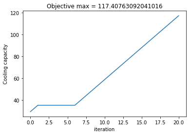

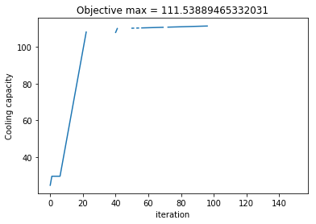

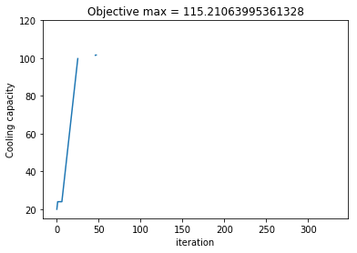

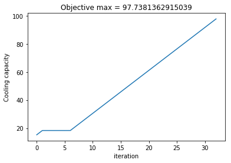

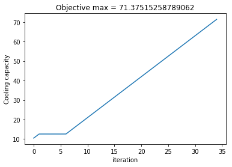

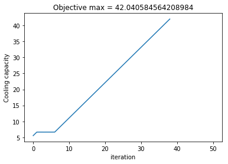

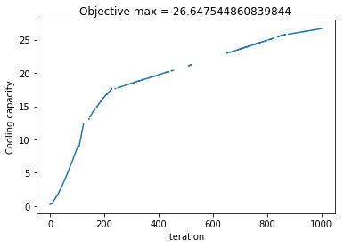

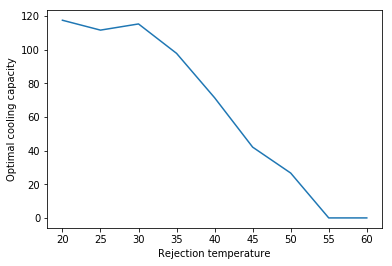

```python
nbplayback('data')
```

```
Note: these files were created by system_aqua1.py
* With hardConstraints = True
* Using default minimize options (BFGS)
* Each boundary condition took about 20 minutes
Loaded the case from  ../data2/system_aqua1_100_90491be93aff6cd2b9d684382bb534f2.pkl
```

```
Loaded the case from  ../data2/system_aqua1_100_262d49e60c00735830979de1523f5d00.pkl
Loaded the case from  ../data2/system_aqua1_100_45ca83277be3e9a5971e1fa2d9ac5b00.pkl
Loaded the case from  ../data2/system_aqua1_100_149c09da3311ef9d24f5c64b18fd1b1d.pkl
```

```
Loaded the case from  ../data2/system_aqua1_100_ddc0526bcf3ef647915f89590fddf49a.pkl
Loaded the case from  ../data2/system_aqua1_100_5c73391993c5e1da1c590c58dd6d3459.pkl
Loaded the case from  ../data2/system_aqua1_100_5ce7666527ab3509ca6c6bfe5799f2d4.pkl
Loaded the case from  ../data2/system_aqua1_100_f430a1079eaddf114aab8afa74eabd87.pkl
Loaded the case from  ../data2/system_aqua1_100_59aa7fe7687bf60e9153231eff92b4a6.pkl
```

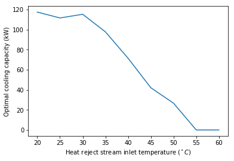

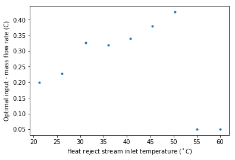

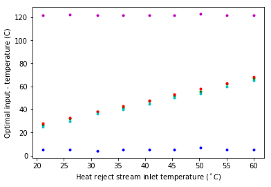

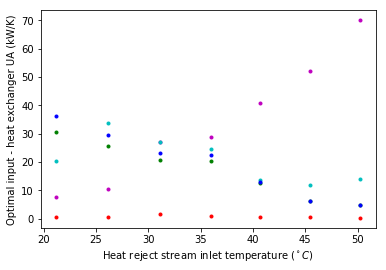

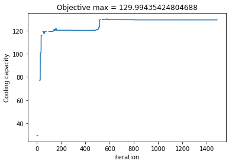

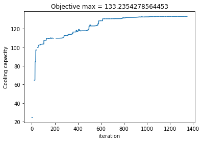

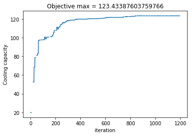

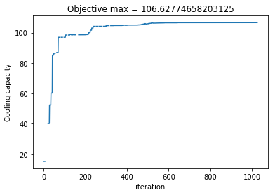

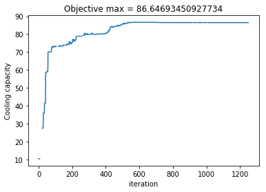

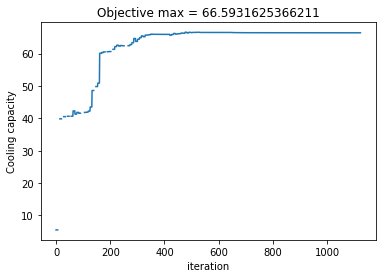

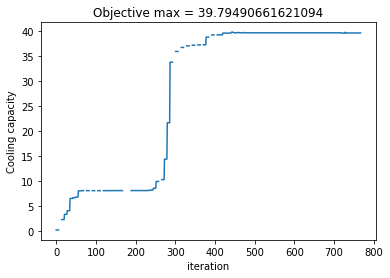

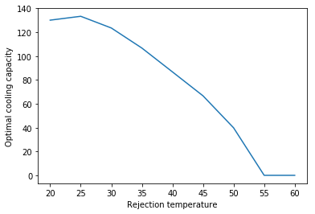

```python
nbplayback('data2')
```

```
This trial contains no readme file.
Loaded the case from  ../data3/system_aqua1_100_90491be93aff6cd2b9d684382bb534f2.pkl
```

```
Loaded the case from  ../data3/system_aqua1_100_262d49e60c00735830979de1523f5d00.pkl
```

```
Loaded the case from  ../data3/system_aqua1_100_45ca83277be3e9a5971e1fa2d9ac5b00.pkl
```

```
Loaded the case from  ../data3/system_aqua1_100_149c09da3311ef9d24f5c64b18fd1b1d.pkl
Loaded the case from  ../data3/system_aqua1_100_ddc0526bcf3ef647915f89590fddf49a.pkl
Loaded the case from  ../data3/system_aqua1_100_5c73391993c5e1da1c590c58dd6d3459.pkl
Loaded the case from  ../data3/system_aqua1_100_5ce7666527ab3509ca6c6bfe5799f2d4.pkl
Loaded the case from  ../data3/system_aqua1_100_f430a1079eaddf114aab8afa74eabd87.pkl
Running the case for  ../data3/system_aqua1_100_59aa7fe7687bf60e9153231eff92b4a6.pkl
```

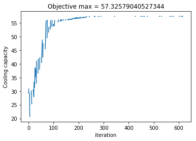

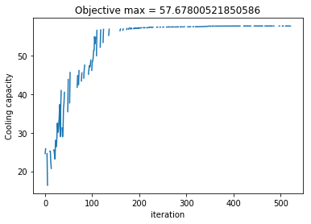

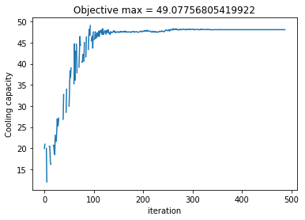

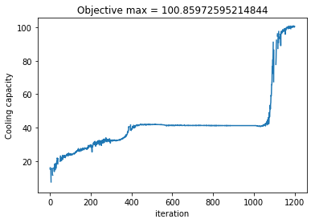

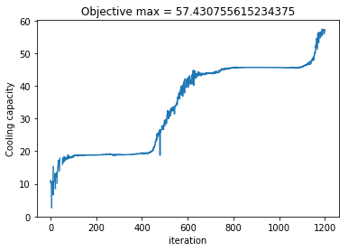

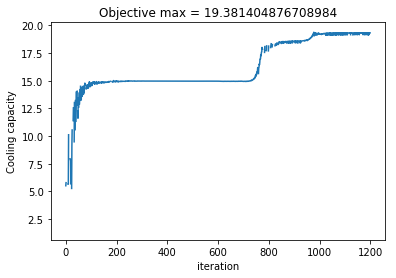

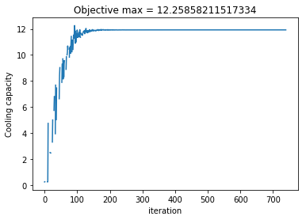

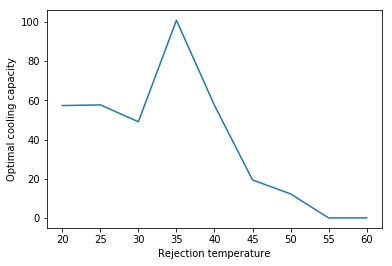

```python
nbplayback('data3')
```